# datalabvis03

# Lab 02

## Ajinkya Shinde

```r
library(here) # to set file path if working from local file
library(tidyverse) #
library(readr)
moma <- read_csv(here::here("data", "artworks-cleaned.csv"))
moma
```

```
## # A tibble: 2,253 x 23
##    title  artist  artist_bio artist_birth_ye~ artist_death_ye~ num_artists
##    <chr>  <chr>   <chr>                 <int>            <dbl>       <int>
##  1 Rope ~ Joan M~ (Spanish,~             1893            1983.           1
##  2 Fire ~ Paul K~ (German, ~             1879            1940.           1
##  3 Portr~ Paul K~ (German, ~             1879            1940.           1
##  4 Guitar Pablo ~ (Spanish,~             1881            1973.           1
##  5 Grand~ Arthur~ (American~             1880            1946.           1
##  6 "\"M'~ Franci~ (French, ~             1879            1953.           1
##  7 Untit~ Blinky~ (German, ~             1943            1977.           1
##  8 Dayli~ Pierre~ (French, ~             1880            1950.           1
##  9 The B~ Paul C~ (French, ~             1839            1906.           1
## 10 Synth~ Enrico~ (Italian,~             1894            1956.           1
## # ... with 2,243 more rows, and 17 more variables: n_female_artists <int>,
## #   n_male_artists <int>, artist_gender <chr>, year_acquired <dbl>,
## #   year_created <int>, circumference_cm <chr>, depth_cm <dbl>,
## #   diameter_cm <chr>, height_cm <dbl>, length_cm <chr>, width_cm <dbl>,
## #   seat_height_cm <chr>, purchase <lgl>, gift <lgl>, exchange <lgl>,
## #   classification <chr>, department <chr>
```

**1.How many paintings (rows) are in moma? How many variables (columns) are in moma? Ans No. of paintings (rows) in moma are 2253 No. of variables (columns) in moma are 23**

```r
moma %>%
  select(title,year_acquired,artist) %>%
  arrange(year_acquired)
```

```
## # A tibble: 2,253 x 3
##    title                                      year_acquired artist
##    <chr>                                              <dbl> <chr>
##  1 House by the Railroad                              1930. Edward Hopper
##  2 Seated Nude                                        1930. Bernard Karfi~
##  3 Daylight Savings Time                              1931. Pierre Roy
##  4 Plums on a Plate                                   1931. Preston Dicki~
##  5 Dr. Mayer-Hermann                                  1932. Otto Dix
##  6 The Bather                                         1934. Paul Cézanne
##  7 Pines and Rocks (Fontainebleau?)                   1934. Paul Cézanne
##  8 Still Life with Ginger Jar, Sugar Bowl, a~         1934. Paul Cézanne
##  9 Still Life with Apples                             1934. Paul Cézanne
## 10 Italian Landscape                                  1934. Arthur B. Dav~
## # ... with 2,243 more rows
```

**2.What is the first painting acquired by MoMA? Which year? Which artist? What title? Ans The first painting with title “House by the railroad” acquired by moma in the year 1930 by the artist Edward Hopper**

```r
moma %>%
  select(title,year_created,artist) %>%
  arrange(year_created)
```

```
## # A tibble: 2,253 x 3
##    title                                    year_created artist
##    <chr>                                           <int> <chr>
##  1 Landscape at Daybreak                            1872 Odilon Redon
##  2 Apache (Man on Horseback)                        1875 Odilon Redon
##  3 Apache (Man on Horseback II)                     1875 Odilon Redon
##  4 Fishing Boat                                     1875 Odilon Redon
##  5 Rocky Peak                                       1875 Odilon Redon
##  6 The Rocky Slope                                  1875 Odilon Redon
##  7 Landscape with Rocks, near Royan                 1875 Odilon Redon
##  8 Still Life with Fruit Dish                       1879 Paul Cézanne
##  9 L'Estaque                                        1879 Paul Cézanne
## 10 On the Cliff at Pourville, Clear Weather         1882 Claude Monet
## # ... with 2,243 more rows
```

```r
distinct(moma %>%
           select(artist))
```

```
## # A tibble: 989 x 1
##    artist
##    <chr>
##  1 Joan Miró
##  2 Paul Klee
##  3 Pablo Picasso
##  4 Arthur Dove
##  5 Francis Picabia
##  6 Blinky Palermo
##  7 Pierre Roy
##  8 Paul Cézanne
##  9 Enrico Prampolini
## 10 Jankel Adler
## # ... with 979 more rows
```

```r
count(moma,vars=artist,sort= TRUE)
```

```
## # A tibble: 989 x 2
##    vars                 n
##    <chr>            <int>
##  1 Pablo Picasso       55
##  2 Henri Matisse       32
##  3 On Kawara           32
##  4 Jacob Lawrence      30
##  5 Batiste Madalena    25
##  6 Jean Dubuffet       25
##  7 Odilon Redon        25
##  8 Ben Vautier         24
##  9 Frank Stella        23
## 10 Philip Guston       23
## # ... with 979 more rows
```

**5.Which artist has the most paintings in the collection? How many paintings are by this artist? Pablo Piccaso has the most paintings with count of 55**

```r
count(moma,artist_gender)
```

```
## # A tibble: 3 x 2
##   artist_gender     n
##   <chr>         <int>
## 1 Female          252
## 2 Male           1991
## 3 <NA>             10
```

**6.How many paintings by male vs female artists? Ans Paintings made by female artists are 252 and paintings made by male artists are 1991**

```r
c_artist_g <-count(moma,artist_gender,artist)
count(c_artist_g,artist_gender)
```

```
## # A tibble: 3 x 2
##   artist_gender    nn
##   <chr>         <int>
## 1 Female          143
## 2 Male            837
## 3 <NA>              9
```

**How many artists of each gender are there? Ans Total female artists are 143 and male artists are 837**

```r
count(moma,year_acquired,sort=TRUE)
```

```
## # A tibble: 88 x 2
##    year_acquired     n
##            <dbl> <int>
##  1         1985.    86
##  2         1942.    71
##  3         1979.    71
##  4         1991.    67
##  5         2005.    67
##  6         1967.    65
##  7         2008.    55
##  8         1961.    45
##  9         1969.    45
## 10         1956.    42
## # ... with 78 more rows
```

**In what year were the most paintings acquired? Ans During 1985,the most paintings were acquired with count equal to 86**

```r
count(moma,year_created,sort=TRUE)
```

```
## # A tibble: 139 x 2
##    year_created     n
##           <int> <int>
##  1         1977    57
##  2         1940    56
##  3         1964    56
##  4         1961    50
##  5         1962    49
##  6         1963    44
##  7         1959    42
##  8         1968    40
##  9         1960    39
## 10         1914    37
## # ... with 129 more rows
```

**In what year were the most paintings Created? Ans During 1977,the most paintings were created with count equal to 57**

```r
moma %>%
  filter(artist_gender == "Female" , n_female_artists == 1) %>%
  select(year_acquired,year_created,artist,title) %>%
  arrange(year_acquired)
```

```
## # A tibble: 252 x 4
##    year_acquired year_created artist                  title
##            <dbl>        <int> <chr>                   <chr>
##  1         1937.         1912 Natalia Goncharova      Landscape, 47
##  2         1938.         1934 Loren MacIver           Shack
##  3         1940.         1940 Loren MacIver           Hopscotch
##  4         1941.         1940 Irene Rice Pereira      Shadows with Painti~
##  5         1941.         1921 Varvara Stepanova       Figure
##  6         1942.         1938 Amelia Peláez Del Casal Still Life in Red
##  7         1942.         1942 Irene Rice Pereira      White Lines
##  8         1942.         1942 Maud Morgan             Musical Squash
##  9         1942.         1942 Raquel Forner           Desolation
## 10         1943.         1940 Frida Kahlo             Self-Portrait with ~
## # ... with 242 more rows
```

**In what year was the first painting by a (solo) female artist acquired? When was that painting created? Which artist? What title? Ans In the year 1937, the first solo female painting was acquired and created in the year 1912 by artist Natalia Goncharova with painting title “Landscape, 47”**

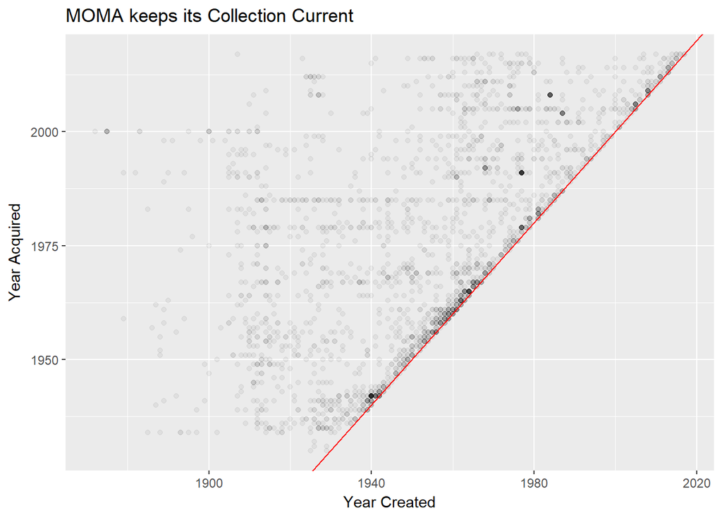

```r
ggplot(moma, aes(x=year_created, y=year_acquired)) + geom_point(alpha=0.05) + labs(x="Year Created", y ="Year Acquired" ) +ggtitle("MOMA keeps its Collection Current")+geom_abline(color="red")
```

**Plot year painted vs year acquired**

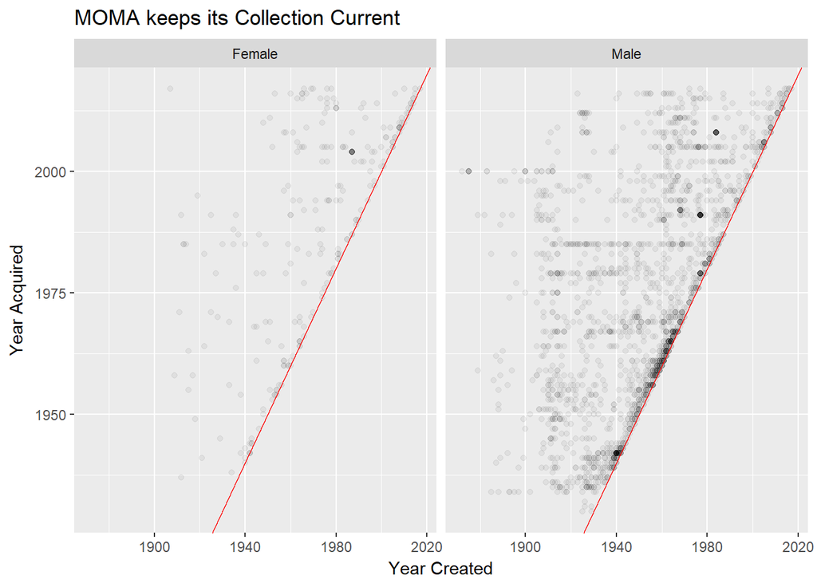

```r
f_moma <- moma %>%
  filter(num_artists == 1)

ggplot(f_moma, aes(x=year_created, y=year_acquired)) + geom_point(alpha=0.05) + labs(x="Year Created", y ="Year Acquired" ) +ggtitle("MOMA keeps its Collection Current")+geom_abline(color="red") + facet_wrap(~artist_gender)
```

**Facet by artist gender**

[figure not shown]

```r
f_moma <- moma %>%
  filter(height_cm<600,width_cm<760) %>%
  mutate(cat_color = case_when (
    (height_cm/width_cm) < 1 ~ "Taller than wide",
    (height_cm/width_cm) > 1 ~ "Wider than tall",
    (height_cm/width_cm) == 1 ~ "Perfect square"
  ))

ggplot(f_moma, aes(x = width_cm, y = height_cm, colour = cat_color)) +
  geom_point(alpha = .5) +
  ggtitle("MoMA Paintings, Tall and Wide") +
  scale_colour_manual(name = "",
                      values = c("gray50", "#FF9900", "#B14CF0")) +      labs(x = "Width", y = "Height")
```

**Plot painting dimensions**

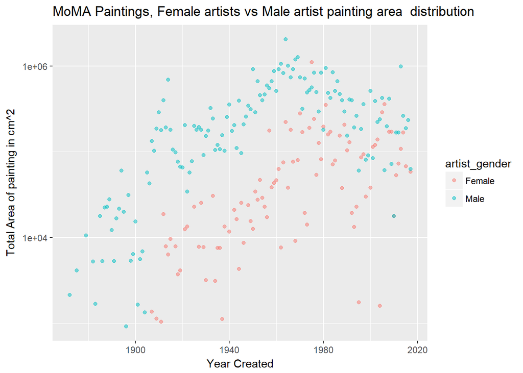

```r
f_moma<-moma %>%
  filter(artist_gender == "Female" | artist_gender == "Male") %>%
  mutate(area=height_cm * width_cm) %>%
  select(year_created,artist_gender,area) %>%
  group_by(year_created,artist_gender) %>%
  summarize(tot_area=sum(area))

ggplot(f_moma, aes(x = year_created, y = tot_area, colour = artist_gender)) +
  geom_point(alpha = .5) +
  ggtitle("MoMA Paintings, Female artists vs Male artist painting area  distribution") +
 labs(x = "Year Created", y = "Total Area of painting in cm^2") +scale_y_log10()
```